# Tercer técnica - ANOVA y MANOVA

# ANOVA

## 1. Librerías

```r
library(tidyverse)
library(car)
```

## 2. Cargar y preparar los datos

```r
datos <- Sample_Superstore
head(datos) # Vista previa
```

|  | Row.ID | Order.ID | Order.Date | Ship.Date | Ship.Mode | Customer.ID | Customer.Name | Segment | Country | City | State | Postal.Code | Region | Product.ID | Category | Sub.Category | Product.Name | Sales | Quantity | Discount | Profit |
| --- | --- | --- | --- | --- | --- | --- | --- | --- | --- | --- | --- | --- | --- | --- | --- | --- | --- | --- | --- | --- | --- |
| 1 | 1 | CA-2016-152156 | 11/8/2016 | 11/11/2016 | Second Class | CG-12520 | Claire Gute | Consumer | United States | Henderson | Kentucky | 42420 | South | FUR-BO-10001798 | Furniture | Bookcases | Bush Somerset Collection Bookcase | 261.9600 | 2 | 0.00 | 41.9136 |
| 2 | 2 | CA-2016-152156 | 11/8/2016 | 11/11/2016 | Second Class | CG-12520 | Claire Gute | Consumer | United States | Henderson | Kentucky | 42420 | South | FUR-CH-10000454 | Furniture | Chairs | Hon Deluxe Fabric Upholstered Stacking Chairs, Rounded Back | 731.9400 | 3 | 0.00 | 219.5820 |
| 3 | 3 | CA-2016-138688 | 6/12/2016 | 6/16/2016 | Second Class | DV-13045 | Darrin Van Huff | Corporate | United States | Los Angeles | California | 90036 | West | OFF-LA-10000240 | Office Supplies | Labels | Self-Adhesive Address Labels for Typewriters by Universal | 14.6200 | 2 | 0.00 | 6.8714 |
| 4 | 4 | US-2015-108966 | 10/11/2015 | 10/18/2015 | Standard Class | SO-20335 | Sean O'Donnell | Consumer | United States | Fort Lauderdale | Florida | 33311 | South | FUR-TA-10000577 | Furniture | Tables | Bretford CR4500 Series Slim Rectangular Table | 957.5775 | 5 | 0.45 | -383.0310 |
| 5 | 5 | US-2015-108966 | 10/11/2015 | 10/18/2015 | Standard Class | SO-20335 | Sean O'Donnell | Consumer | United States | Fort Lauderdale | Florida | 33311 | South | OFF-ST-10000760 | Office Supplies | Storage | Eldon Fold 'N Roll Cart System | 22.3680 | 2 | 0.20 | 2.5164 |
| 6 | 6 | CA-2014-115812 | 6/9/2014 | 6/14/2014 | Standard Class | BH-11710 | Brosina Hoffman | Consumer | United States | Los Angeles | California | 90032 | West | FUR-FU-10001487 | Furniture | Furnishings | Eldon Expressions Wood and Plastic Desk Accessories, Cherry Wood | 48.8600 | 7 | 0.00 | 14.1694 |

```r
str(datos) # Estructura
```

```
## 'data.frame':    9994 obs. of  21 variables:
##  $ Row.ID       : int  1 2 3 4 5 6 7 8 9 10 ...
##  $ Order.ID     : chr  "CA-2016-152156" "CA-2016-152156" "CA-2016-138688" "US-2015-108966" ...
##  $ Order.Date   : chr  "11/8/2016" "11/8/2016" "6/12/2016" "10/11/2015" ...
##  $ Ship.Date    : chr  "11/11/2016" "11/11/2016" "6/16/2016" "10/18/2015" ...
##  $ Ship.Mode    : chr  "Second Class" "Second Class" "Second Class" "Standard Class" ...
##  $ Customer.ID  : chr  "CG-12520" "CG-12520" "DV-13045" "SO-20335" ...
##  $ Customer.Name: chr  "Claire Gute" "Claire Gute" "Darrin Van Huff" "Sean O'Donnell" ...
##  $ Segment      : chr  "Consumer" "Consumer" "Corporate" "Consumer" ...
##  $ Country      : chr  "United States" "United States" "United States" "United States" ...
##  $ City         : chr  "Henderson" "Henderson" "Los Angeles" "Fort Lauderdale" ...
##  $ State        : chr  "Kentucky" "Kentucky" "California" "Florida" ...
##  $ Postal.Code  : int  42420 42420 90036 33311 33311 90032 90032 90032 90032 90032 ...
##  $ Region       : chr  "South" "South" "West" "South" ...
##  $ Product.ID   : chr  "FUR-BO-10001798" "FUR-CH-10000454" "OFF-LA-10000240" "FUR-TA-10000577" ...
##  $ Category     : chr  "Furniture" "Furniture" "Office Supplies" "Furniture" ...
##  $ Sub.Category : chr  "Bookcases" "Chairs" "Labels" "Tables" ...
##  $ Product.Name : chr  "Bush Somerset Collection Bookcase" "Hon Deluxe Fabric Upholstered Stacking Chairs, Rounded Back" "Self-Adhesive Address Labels for Typewriters by Universal" "Bretford CR4500 Series Slim Rectangular Table" ...
##  $ Sales        : num  262 731.9 14.6 957.6 22.4 ...
##  $ Quantity     : int  2 3 2 5 2 7 4 6 3 5 ...
##  $ Discount     : num  0 0 0 0.45 0.2 0 0 0.2 0.2 0 ...
##  $ Profit       : num  41.91 219.58 6.87 -383.03 2.52 ...
```

### 2.1. Cambiar la variable ‘Region’ por factor

Se cambia ‘Region’ a factor ya que es una variable categorica que nos esta definiendo los lugares de compras (Central, East, South, West).

```r
datos$Region <- as.factor(datos$Region)
class(datos$Region) # Saber si se realizo el cambio
```

```
## [1] "factor"
```

## 3. Análisis Exploratorio

```r
summary(datos$Profit) # Resumen estadistico
```

```
##      Min.   1st Qu.    Median      Mean   3rd Qu.      Max.
## -6599.978     1.729     8.666    28.657    29.364  8399.976
```

```r
table(datos$Region) # Cuantas observaciones tiene la variable
```

```
##
## Central    East   South    West
##    2323    2848    1620    3203
```

### 3.1. Calcular la media de ganancia - Profit por Region

```r
datos %>%
  group_by(Region) %>%
  summarise(
    media = mean(Profit, na.rm = TRUE),
  )
```

| Region | media |
| --- | --- |
| Central | 17.09271 |
| East | 32.13581 |
| South | 28.85767 |
| West | 33.84903 |

Podemos observar que la region West presenta la mayor ganacia promedio, seguida por East, mientras que South mantiene un nivel intermedio y la region Central nos muestra la menor ganancia promedio, se podria decir que si existen diferencias entre las regiones.

## 4. Verificación de los supuestos

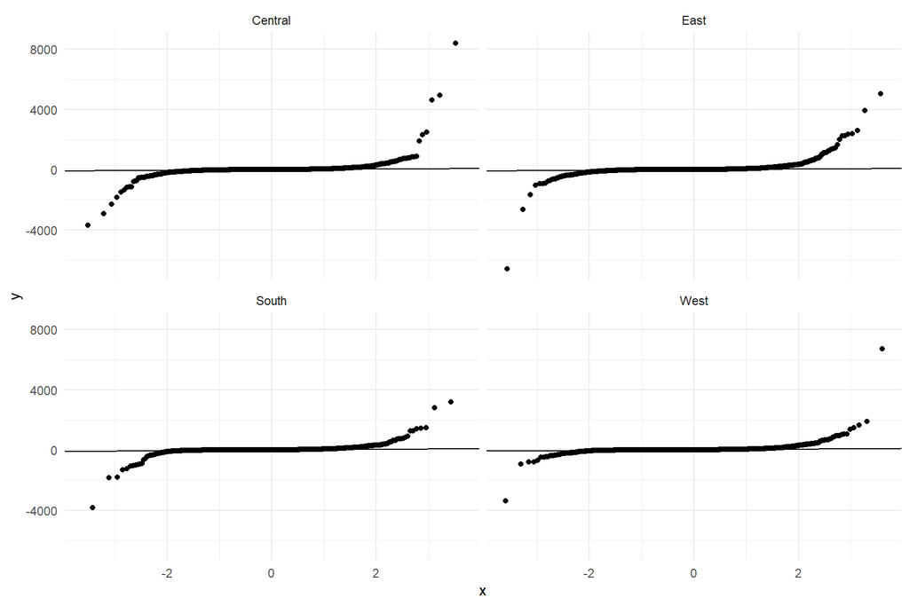

```r
# QQ-plot por Region
ggplot(datos, aes(sample = Profit)) +
  stat_qq() + stat_qq_line() +
  facet_wrap(~ Region) +
  theme_minimal()
```

```r
#Shapiro
set.seed(123)
datos %>%
  group_by(Region) %>%
  summarise(
    p_value = shapiro.test(sample(Profit, min(500, n())))$p.value
  )
```

| Region | p_value |
| --- | --- |
| Central | 4.899895e-33 |
| East | 1.151311e-38 |
| South | 1.242894e-39 |
| West | 1.410645e-42 |

```r
# Prueba de Levene (homogeneidad de varianzas)
leveneTest(Profit ~ Region, data = datos)
```

|  | Df | F value | Pr(>F) |
| --- | --- | --- | --- |
| group | 3 | 5.578603 | 0.000805897 |
|  | 9990 | NA | NA |

## 5. Planteamiento de la hipótesis

H0: Las medias de Profit son iguales entre las 4 regiones. H1: Al menos una media difiere de las demás. Por convención científica significa que acepta hasta un 5% de riesgo de rechazar H0 siendo verdadera.

## 6. Prueba ANOVA

```r
anova_resultado <- aov(Profit ~ Region, data = datos)
summary(anova_resultado)
```

```
##               Df    Sum Sq Mean Sq F value Pr(>F)
## Region         3    431537  143846   2.622 0.0489 *
## Residuals   9990 547962299   54851
## ---
## Signif. codes:  0 '***' 0.001 '**' 0.01 '*' 0.05 '.' 0.1 ' ' 1
```

Como el valor p es menor que 0.05, se rechaza la hipotesis nula.

## 7. Comparaciones múltiples

```r
TukeyHSD(anova_resultado)
```

```
##   Tukey multiple comparisons of means
##     95% family-wise confidence level
##
## Fit: aov(formula = Profit ~ Region, data = datos)
##
## $Region
##                    diff         lwr      upr     p adj
## East-Central  15.043099  -1.7808459 31.86704 0.0986433
## South-Central 11.764964  -7.7140259 31.24395 0.4064931
## West-Central  16.756323   0.3565617 33.15608 0.0430362
## South-East    -3.278135 -22.0049635 15.44869 0.9696845
## West-East      1.713224 -13.7856543 17.21210 0.9920144
## West-South     4.991359 -13.3553351 23.33805 0.8974796
```

- East-Central: p = 0.0986433 -> no hay diferencia significativa.
- South-Central: p = 0.4064931 -> no hay diferencia significativa.
- West-Central: p = 0.0430362 -> sí hay diferencia significativa.
- South-East: p = 0.9696845 -> no hay diferencia significativa.
- West-East: p = 0.9920144 -> no hay diferencia significativa.
- West-South: p = 0.8974796 -> no hay diferencia significativa.

## 8. Visualización

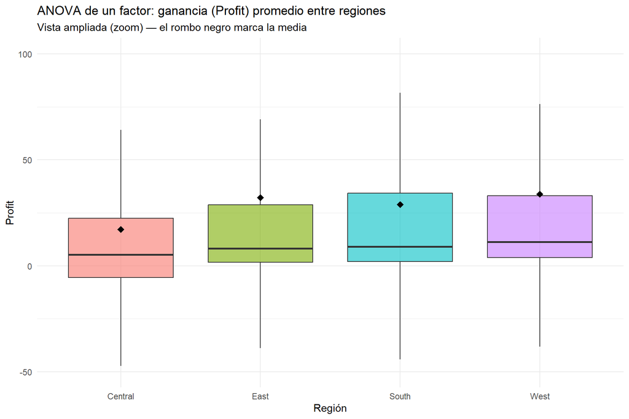

```r
ggplot(datos, aes(x = Region, y = Profit, fill = Region)) +
  geom_boxplot(alpha = 0.6, outlier.shape = NA) +  # oculta los outliers extremos
  stat_summary(fun = mean, geom = "point", shape = 18, size = 3, color = "black") +
  coord_cartesian(ylim = c(-50, 100)) +  # hace "zoom" sin eliminar datos reales
  labs(
    title = "ANOVA de un factor: ganancia (Profit) promedio entre regiones",
    subtitle = "Vista ampliada (zoom) — el rombo negro marca la media",
    x = "Región", y = "Profit"
  ) +
  theme_minimal() +
  theme(legend.position = "none")
```

# MANOVA

## 1. Librerías

```r
library(tidyverse)
library(biotools)
library(car)
```

## 2. Cargar los datos

```r
datos2 <- Sample_Superstore
```

### 2.1 Pasamos las variables Category y Segment en factores

```r
datos2$Category <- factor(datos2$Category)
datos2$Segment  <- factor(datos2$Segment)

str(datos2)
```

```
## 'data.frame':    9994 obs. of  21 variables:
##  $ Row.ID       : int  1 2 3 4 5 6 7 8 9 10 ...
##  $ Order.ID     : chr  "CA-2016-152156" "CA-2016-152156" "CA-2016-138688" "US-2015-108966" ...
##  $ Order.Date   : chr  "11/8/2016" "11/8/2016" "6/12/2016" "10/11/2015" ...
##  $ Ship.Date    : chr  "11/11/2016" "11/11/2016" "6/16/2016" "10/18/2015" ...
##  $ Ship.Mode    : chr  "Second Class" "Second Class" "Second Class" "Standard Class" ...
##  $ Customer.ID  : chr  "CG-12520" "CG-12520" "DV-13045" "SO-20335" ...
##  $ Customer.Name: chr  "Claire Gute" "Claire Gute" "Darrin Van Huff" "Sean O'Donnell" ...
##  $ Segment      : Factor w/ 3 levels "Consumer","Corporate",..: 1 1 2 1 1 1 1 1 1 1 ...
##  $ Country      : chr  "United States" "United States" "United States" "United States" ...
##  $ City         : chr  "Henderson" "Henderson" "Los Angeles" "Fort Lauderdale" ...
##  $ State        : chr  "Kentucky" "Kentucky" "California" "Florida" ...
##  $ Postal.Code  : int  42420 42420 90036 33311 33311 90032 90032 90032 90032 90032 ...
##  $ Region       : chr  "South" "South" "West" "South" ...
##  $ Product.ID   : chr  "FUR-BO-10001798" "FUR-CH-10000454" "OFF-LA-10000240" "FUR-TA-10000577" ...
##  $ Category     : Factor w/ 3 levels "Furniture","Office Supplies",..: 1 1 2 1 2 1 2 3 2 2 ...
##  $ Sub.Category : chr  "Bookcases" "Chairs" "Labels" "Tables" ...
##  $ Product.Name : chr  "Bush Somerset Collection Bookcase" "Hon Deluxe Fabric Upholstered Stacking Chairs, Rounded Back" "Self-Adhesive Address Labels for Typewriters by Universal" "Bretford CR4500 Series Slim Rectangular Table" ...
##  $ Sales        : num  262 731.9 14.6 957.6 22.4 ...
##  $ Quantity     : int  2 3 2 5 2 7 4 6 3 5 ...
##  $ Discount     : num  0 0 0 0.45 0.2 0 0 0.2 0.2 0 ...
##  $ Profit       : num  41.91 219.58 6.87 -383.03 2.52 ...
```

```r
head(datos2)
```

|  | Row.ID | Order.ID | Order.Date | Ship.Date | Ship.Mode | Customer.ID | Customer.Name | Segment | Country | City | State | Postal.Code | Region | Product.ID | Category | Sub.Category | Product.Name | Sales | Quantity | Discount | Profit |
| --- | --- | --- | --- | --- | --- | --- | --- | --- | --- | --- | --- | --- | --- | --- | --- | --- | --- | --- | --- | --- | --- |
| 1 | 1 | CA-2016-152156 | 11/8/2016 | 11/11/2016 | Second Class | CG-12520 | Claire Gute | Consumer | United States | Henderson | Kentucky | 42420 | South | FUR-BO-10001798 | Furniture | Bookcases | Bush Somerset Collection Bookcase | 261.9600 | 2 | 0.00 | 41.9136 |
| 2 | 2 | CA-2016-152156 | 11/8/2016 | 11/11/2016 | Second Class | CG-12520 | Claire Gute | Consumer | United States | Henderson | Kentucky | 42420 | South | FUR-CH-10000454 | Furniture | Chairs | Hon Deluxe Fabric Upholstered Stacking Chairs, Rounded Back | 731.9400 | 3 | 0.00 | 219.5820 |
| 3 | 3 | CA-2016-138688 | 6/12/2016 | 6/16/2016 | Second Class | DV-13045 | Darrin Van Huff | Corporate | United States | Los Angeles | California | 90036 | West | OFF-LA-10000240 | Office Supplies | Labels | Self-Adhesive Address Labels for Typewriters by Universal | 14.6200 | 2 | 0.00 | 6.8714 |
| 4 | 4 | US-2015-108966 | 10/11/2015 | 10/18/2015 | Standard Class | SO-20335 | Sean O'Donnell | Consumer | United States | Fort Lauderdale | Florida | 33311 | South | FUR-TA-10000577 | Furniture | Tables | Bretford CR4500 Series Slim Rectangular Table | 957.5775 | 5 | 0.45 | -383.0310 |
| 5 | 5 | US-2015-108966 | 10/11/2015 | 10/18/2015 | Standard Class | SO-20335 | Sean O'Donnell | Consumer | United States | Fort Lauderdale | Florida | 33311 | South | OFF-ST-10000760 | Office Supplies | Storage | Eldon Fold 'N Roll Cart System | 22.3680 | 2 | 0.20 | 2.5164 |
| 6 | 6 | CA-2014-115812 | 6/9/2014 | 6/14/2014 | Standard Class | BH-11710 | Brosina Hoffman | Consumer | United States | Los Angeles | California | 90032 | West | FUR-FU-10001487 | Furniture | Furnishings | Eldon Expressions Wood and Plastic Desk Accessories, Cherry Wood | 48.8600 | 7 | 0.00 | 14.1694 |

```r
table(datos2$Category, datos2$Segment)
```

```
##
##                   Consumer Corporate Home Office
##   Furniture           1113       646         362
##   Office Supplies     3127      1820        1079
##   Technology           951       554         342
```

## 3. Análisis exploratorio

```r
datos2 %>%
  group_by(Category, Segment) %>%
  summarise(media_sales = mean(Sales),
            media_profit = mean(Profit),
            .groups = "drop")
```

| Category | Segment | media_sales | media_profit |
| --- | --- | --- | --- |
| Furniture | Consumer | 351.3471 | 6.281293 |
| Furniture | Corporate | 354.5198 | 11.741201 |
| Furniture | Home Office | 336.8251 | 10.705465 |
| Office Supplies | Consumer | 116.3902 | 18.014174 |
| Office Supplies | Corporate | 126.7453 | 22.102923 |
| Office Supplies | Home Office | 115.3090 | 24.034439 |
| Technology | Consumer | 427.3395 | 74.445646 |
| Technology | Corporate | 444.8558 | 79.723823 |
| Technology | Home Office | 535.9767 | 89.152458 |

```r
cor(datos2$Sales, datos2$Profit) #Correlacion
```

```
## [1] 0.4790643
```

## 4. Supuestos

### 4.1 Vamos a evaluar la normalidad

Usamos Henze-Zirkler.

```r
henze_zirkler <- function(X) {
  X <- as.matrix(X)
  n <- nrow(X); p <- ncol(X)
  S <- cov(X); Sinv <- solve(S)
  Xc <- scale(X, center = TRUE, scale = FALSE)

  G  <- Xc %*% Sinv %*% t(Xc)
  Di <- diag(G)
  Dij <- outer(Di, Di, "+") - 2 * G
  Dij[Dij < 0] <- 0

  beta <- (1 / sqrt(2)) * ((n * (2 * p + 1) / 4)^(1 / (p + 4)))
  b2   <- beta^2
  t1 <- sum(exp(-b2 / 2 * Dij)) / n^2
  t2 <- -2 * (1 + b2)^(-p/2) * sum(exp(-b2 / (2 * (1 + b2)) * Di)) / n
  t3 <- (1 + 2 * b2)^(-p/2)
  HZ <- n * (t1 + t2 + t3)
  wb  <- (1 + b2) * (1 + 3 * b2); a <- 1 + 2 * b2
  mu  <- 1 - a^(-p/2) * (1 + p * b2 / a + p * (p + 2) * b2^2 / (2 * a^2))
  si2 <- 2 * (1 + 4 * b2)^(-p/2) +
    2 * a^(-p) * (1 + 2 * p * b2^2 / a^2 + 3 * p * (p + 2) * b2^4 / (4 * a^4)) -
    4 * wb^(-p/2) * (1 + 3 * p * b2^2 / (2 * wb) + p * (p + 2) * b2^4 / (2 * wb^2))
  pmu <- log(sqrt(mu^4 / (si2 + mu^2)))
  psi <- sqrt(log((si2 + mu^2) / mu^2))
  pval <- 1 - pnorm((log(HZ) - pmu) / psi)
  cat("Prueba de Henze-Zirkler (normalidad multivariada)\n")
  cat(sprintf("  Estadistico HZ : %.4f\n", HZ))
  cat(sprintf("  Valor p        : %.4f\n", pval))
  cat(sprintf("  Normalidad MVN : %s\n", ifelse(pval > 0.05, "SI (p > 0.05)", "NO (p <= 0.05)")))
  invisible(list(HZ = HZ, p.value = pval, MVN = pval > 0.05))
}

vd <- datos2[, c("Sales", "Profit")]
henze_zirkler(vd)
```

```
## Prueba de Henze-Zirkler (normalidad multivariada)
##   Estadistico HZ : 4426.7026
##   Valor p        : 0.0000
##   Normalidad MVN : NO (p <= 0.05)
```

### 4.2 Normalidad univariada Shapiro-Wilk

```r
mod_lm <- lm(cbind(Sales, Profit) ~ Category * Segment,
             data = datos2)
res <- residuals(mod_lm) #Residuales del modelo

set.seed(123)
shapiro.test(sample(res[, "Sales"], 5000))    #espero p>0.05
```

```
##
##  Shapiro-Wilk normality test
##
## data:  sample(res[, "Sales"], 5000)
## W = 0.3573, p-value < 2.2e-16
```

```r
shapiro.test(sample(res[, "Profit"], 5000))   #espero p>0.05
```

```
##
##  Shapiro-Wilk normality test
##
## data:  sample(res[, "Profit"], 5000)
## W = 0.27522, p-value < 2.2e-16
```

### 4.3 Homogeneidad de matrices de covarianza

```r
biotools::boxM(datos2[, c("Sales", "Profit")],
               interaction(datos2$Category, datos2$Segment))
```

```
##
##  Box's M-test for Homogeneity of Covariance Matrices
##
## data:  datos2[, c("Sales", "Profit")]
## Chi-Sq (approx.) = 9647.5, df = 24, p-value < 2.2e-16
```

### 4.4 Homogeneidad de varianzas univariadas

```r
leveneTest(Sales ~ Category * Segment, data = datos2)
```

|  | Df | F value | Pr(>F) |
| --- | --- | --- | --- |
| group | 8 | 47.25806 | 2.696903e-75 |
|  | 9985 | NA | NA |

```r
leveneTest(Profit ~ Category * Segment, data = datos2)
```

|  | Df | F value | Pr(>F) |
| --- | --- | --- | --- |
| group | 8 | 21.08536 | 4.689603e-32 |
|  | 9985 | NA | NA |

## 5. Planteo de Hipótesis

Sea mu = (mu_Sales, mu_Profit) el vector de medias.

**Efecto CATEGORY:**

- H0: mu_Furniture = mu_OfficeSupplies = mu_Technology
- H1: al menos un vector de medias difiere entre categorías de producto

**Efecto SEGMENT:**

- H0: mu_Consumer = mu_Corporate = mu_HomeOffice
- H1: al menos un vector de medias difiere entre segmentos de cliente

**INTERACCION Category x Segment:**

- H0: el efecto del segmento es el mismo para las tres categorías de producto (sin interacción)
- H1: el efecto del segmento depende de la categoría de producto

## 6. Ajuste de modelo MANOVA

```r
modelo <- manova(cbind(Sales, Profit) ~ Category * Segment,
                 data = datos2)
summary(modelo, test = "Pillai")
```

```
##                    Df   Pillai approx F num Df den Df Pr(>F)
## Category            2 0.061526  158.458      4  19970 <2e-16 ***
## Segment             2 0.000194    0.483      4  19970 0.7480
## Category:Segment    4 0.000832    1.039      8  19970 0.4036
## Residuals        9985
## ---
## Signif. codes:  0 '***' 0.001 '**' 0.01 '*' 0.05 '.' 0.1 ' ' 1
```

## 7. ANOVA univariado de seguimiento

```r
summary.aov(modelo)
```

```
##  Response Sales :
##                    Df     Sum Sq  Mean Sq  F value Pr(>F)
## Category            2  195881745 97940872 265.5638 <2e-16 ***
## Segment             2     453622   226811   0.6150 0.5407
## Category:Segment    4    2786415   696604   1.8888 0.1094
## Residuals        9985 3682503730   368804
## ---
## Signif. codes:  0 '***' 0.001 '**' 0.01 '*' 0.05 '.' 0.1 ' ' 1
##
##  Response Profit :
##                    Df    Sum Sq Mean Sq F value Pr(>F)
## Category            2   5898009 2949004 54.2891 <2e-16 ***
## Segment             2     87244   43622  0.8030 0.4480
## Category:Segment    4     19149    4787  0.0881 0.9862
## Residuals        9985 542389434   54320
## ---
## Signif. codes:  0 '***' 0.001 '**' 0.01 '*' 0.05 '.' 0.1 ' ' 1
```

## 8. Visualización

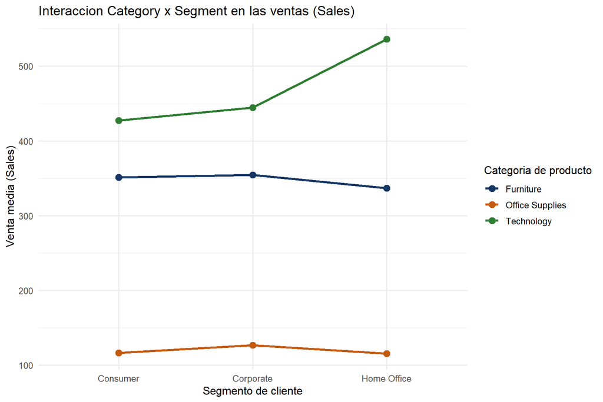

```r
medias <- datos2 %>%
  group_by(Category, Segment) %>%
  summarise(media_sales = mean(Sales), .groups = "drop")

ggplot(medias, aes(x = Segment, y = media_sales,
                   color = Category, group = Category)) +
  geom_line(linewidth = 1.1) +
  geom_point(size = 3) +
  labs(title = "Interaccion Category x Segment en las ventas (Sales)",
       x = "Segmento de cliente", y = "Venta media (Sales)",
       color = "Categoria de producto") +
  scale_color_manual(values = c("#153664", "#C55A11", "#2E7D32")) +
  theme_minimal(base_size = 12)
```